# ML for dummies

Pietro Franceschi

12/11/2020

```r
library(tidyverse)
```

## Introduction

The objective of this demo, and of the subsequent DIY, is to make you familiar with the basic ideas behind ML tuning and validation.

To do that in a simple way we will try to solve in the ML way the problem of fitting a line through a set of points. It is clear that this could be easily done by regression, but the idea is not to use mathematics, but brute force …

As we discussed in the lecture to peform machine learnign we need

> 1. collect data
> 2. propose a model
> 3. propose a *loss function* used to fit the model to the data
> 4. find the best model
> 5. do the predictions

## Get the data

I create a dummy dataset …

```r
## This is the vector of x
x <- seq(0,10,0.3)

## I put everything in a tibble
dummy_data <- tibble(x = x,
                     y = 2*x+5 + rnorm(length(x),0,2))

dummy_data
```

```
## # A tibble: 34 × 2
##        x     y
##    <dbl> <dbl>
##  1   0    3.99
##  2   0.3  2.76
##  3   0.6  6.46
##  4   0.9 10.7
##  5   1.2  9.00
##  6   1.5 10.3
##  7   1.8  9.32
##  8   2.1  7.98
##  9   2.4  9.40
## 10   2.7  9.85
## # … with 24 more rows
```

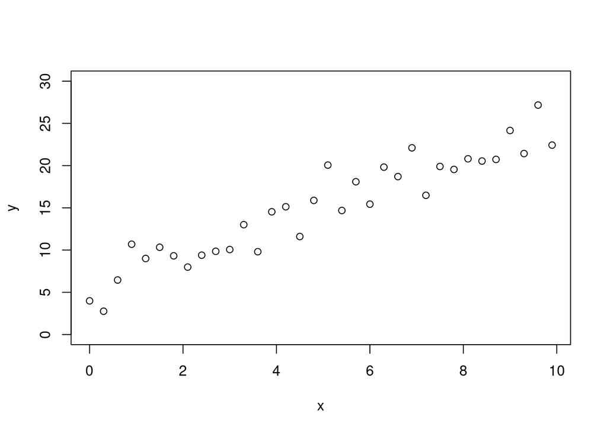

```r
plot(y~x, data = dummy_data , ylim = c(0,30))
```

## The model

I propose to fit to these data a straight line, from my background of mathematics I know that a straight line has an equation like this

$$y = bx + a$$

My “model” is rather simple, and has two parameters which should be found to identify the “best” model (of this complexity)

- $b$ is the slope
- $a$ is the intercept with the $y$ axis (where $x=0$)

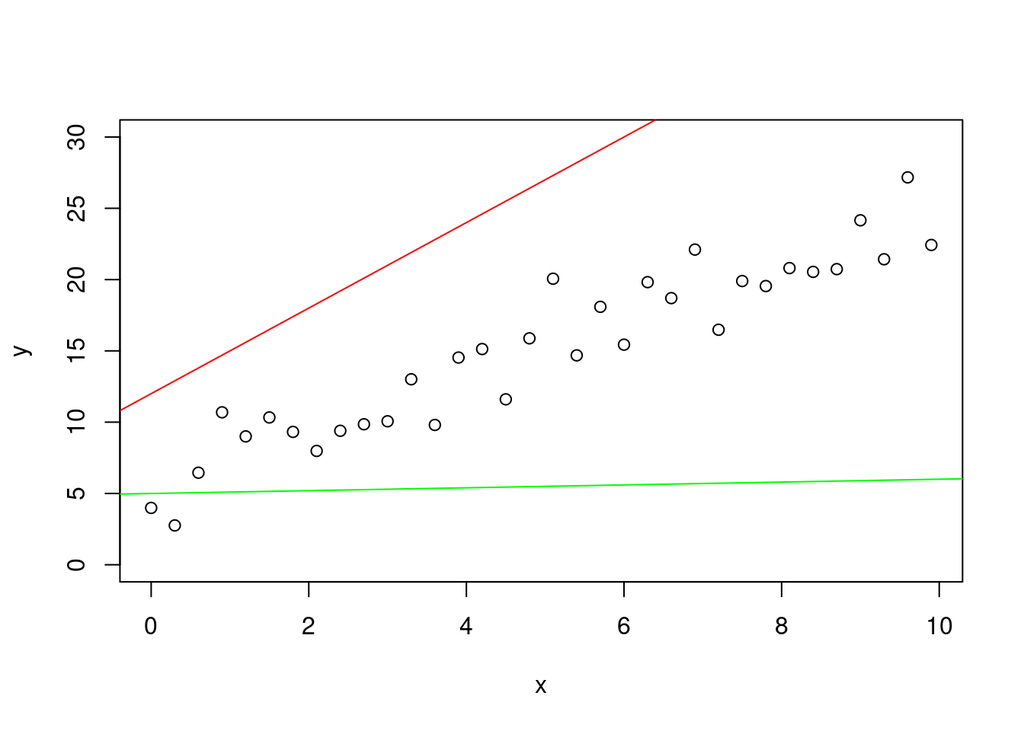

```r
plot(y~x, data = dummy_data , ylim = c(0,30))
abline(a = 12, b=3, col = "red")
abline(a = 5, b=0.1, col = "green")
```

The red and green lines here show two possible “forms” of my model.

## Loss Function

Ok, now I decide to use as loss function the sum of squared differences from the value predicted from the model and the one I observe. Graphically I’m using the sum of the squared distances between a line and the observed points

For a specific model

```r
## here I add the predictions to my data
dummy_data$pred <- dummy_data$x*3 + 12
```

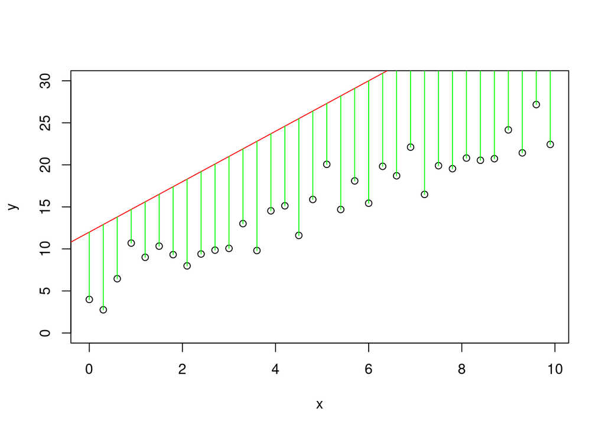

```r
plot(y~x, data = dummy_data , ylim = c(0,30))
abline(a = 12, b=3, col = "red")
segments(x0 = dummy_data$x, y0 = dummy_data$y, y1 = dummy_data$pred, col = "green")
```

The green lines are the residuals, so the “loss” of this model will be the squared sum of the length of the green segments.